# Cancer Screening programmes in Scotland

Lesley Duff

2023-11-13

# Screening

## Background

### Scottish Bowel Screening Programme

Commenced in 2007 with a full rollout across all health boards by 2009.

People aged 50-74 years are invited every two years to complete a home bowel screening test.  
75 and over can self-refer.

### Uptake

The [Healthcare Improvement Scotland (HIS) standard target](https://www.healthcareimprovementscotland.org/our_work/standards_and_guidelines/stnds/bowel_screening_standards.aspx) for bowel screening is **uptake is 60%**.

Based on [Scottish bowel screening programme statistics For the period of invitations from May 2020 to April 2022](https://publichealthscotland.scot/publications/scottish-bowel-screening-programme-statistics/scottish-bowel-screening-programme-statistics-for-the-period-of-invitations-from-may-2020-to-april-2022/)

“The proportion of invites which are returned as a correctly completed kit (i.e. a positive or negative test result). It is a key measure of the acceptability of the test to the public.”

Health Improvement Scotland [Bowel screening standards: August 2023 (PDF)](https://www.healthcareimprovementscotland.org/his/idoc.ashx?docid=49b039aa-f6cf-42aa-8fda-3d6bc165bd21&version=-1).

## Analysis

### All Scotland

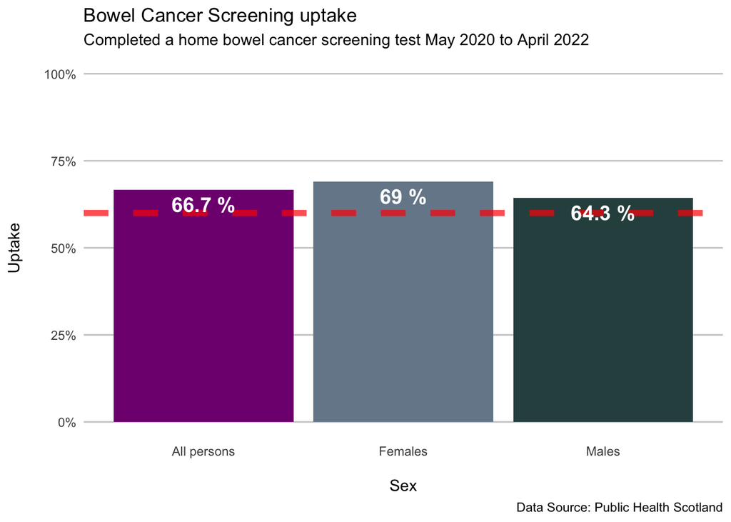

The red dashed horizontal line marks the Health Improvement Scotland standard **target of 60%**.

This shows that in the current Bowel Cancer Screening latest results around 2/3 of the people invited via the screening programme are taking up the offer.

Females are more likely to return the tests than males.

Bowel Cancer Screening Uptake

Data for May 2020 to April 2022

| Sex | Health Board | Uptake (%) |
| --- | --- | --- |
| All persons | Scotland | 66.7 |
| Females | Scotland | 69.1 |
| Males | Scotland | 64.3 |

Data Source: Public Health Scotland

For the most recent round of testing the target has been met and exceeded by a clear margin.

Continue to enhance communication to try and engage the remaining third of the general public making more efforts to target males.

**Conclusion: 60% target is being met but room for improvement**.

### All Uptake by Health Board and Sex

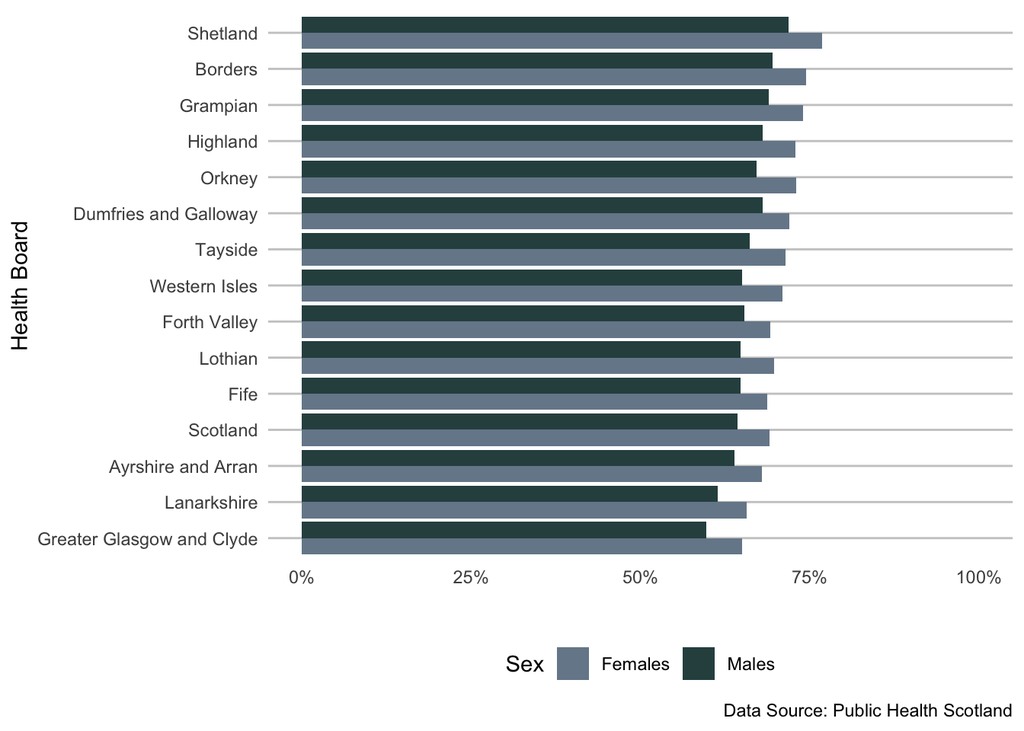

Females return their testing kits more than males for every Health Board in Scotland.

Just to confirm the numbers for each Health Board the following table is ordered by those with the lowest uptake first.

Bowel Cancer Screening Uptake

Data for May 2020 to April 2022

| Sex | Health Board | Uptake (%) |
| --- | --- | --- |
| All persons | Greater Glasgow and Clyde | 62.4 |
| All persons | Lanarkshire | 63.6 |
| All persons | Ayrshire and Arran | 66.0 |
| All persons | Fife | 66.8 |
| All persons | Lothian | 67.3 |
| All persons | Forth Valley | 67.3 |
| All persons | Western Isles | 67.9 |
| All persons | Tayside | 68.8 |
| All persons | Dumfries and Galloway | 70.1 |
| All persons | Orkney | 70.1 |
| All persons | Highland | 70.5 |
| All persons | Grampian | 71.5 |
| All persons | Borders | 72.0 |
| All persons | Shetland | 74.3 |

Data Source: Public Health Scotland

- Highest: Shetland (74.3%)
- Lowest: Greater Glasgow and Clyde (62.4%)

There is almost 12% difference between the highest and lowest uptakes between health boards, this seems seems relatively large. In general, the further the health board is from the Central Belt of Scotland the better the public participation.

Other research suggests that there may be a link in general between deprivation and uptake of screening programmes. In Scotland the Bowel Cancer screening kits are sent directly to the home of a person and there is no charge for posting them to return the kit. If deprivation is a factor, superficially it wouldn’t seem like it would be for reasons of cost, so perhaps there are more complex reasons around education and awareness of importance or others that need teasing out.

**Suggestion:**

There should be some greater examination of what other health boards can learn about the roll out in more successful areas like Shetland. In general the further away from the central belt, the more successful. And more efforts to educate and inform the public, particularly males over 60 and other age groups more at risk.

Try the interactive Cancer Risk Tool that accompanies the analysis report on incidences with the settings **(All age ranges, Male, Colorectal cancer)**